# covid-19

Alexey Sokolov

2022-07-18

### Data source and overview

Data was downloaded from this website - https://github.com/CSSEGISandData/COVID-19/tree/master/csse_covid_19_data/csse_covid_19_time_series Data represents daily time series of COVID-19 cases including confirmed, recovered and deaths

## Import data

here we just use read_csv data function that takes URL as a parameter

```r
url_in <- "https://raw.githubusercontent.com/CSSEGISandData/COVID-19/master/csse_covid_19_data/csse_covid_19_time_series/"
file_names <- c("time_series_covid19_confirmed_global.csv",
               "time_series_covid19_deaths_global.csv",
               "time_series_covid19_confirmed_US.csv",
               "time_series_covid19_deaths_US.csv")
urls <- str_c(url_in, file_names)

global_cases <- read_csv(urls[1])
global_deaths <- read_csv(urls[2])
us_cases <- read_csv(urls[3])
us_deaths <- read_csv(urls[4])
```

## Tidy data

here we “lengthen” data (decrease the number of columns and increase the number of rows). Previously we had column for every possible date and now we put this information in rows using pivot_longer function. Also we remove Lat and Long as we won’t use it in further analysis. And finally we convert date to date format using mdy function

```r
global_cases <- global_cases %>%
  pivot_longer(cols = -c(`Province/State`, `Country/Region`, Lat, Long),
               names_to = "date",
               values_to = "cases") %>%
  select(-c(Lat, Long))

global_deaths <- global_deaths %>%
  pivot_longer(cols = -c(`Province/State`, `Country/Region`, Lat, Long),
               names_to = "date",
               values_to = "deaths") %>%
  select(-c(Lat, Long))


us_cases <- us_cases %>%
  pivot_longer(cols = - (UID:Combined_Key),
               names_to = "date",
               values_to = "cases") %>%
  select(Admin2:cases) %>%
  mutate(date = mdy(date)) %>%
  select(-c(Lat, Long_))

us_deaths <- us_deaths %>%
  pivot_longer(cols = -(UID:Population),
               names_to = "date",
               values_to = "deaths") %>%
  select(Admin2:deaths) %>%
  mutate(date = mdy(date)) %>%
  select(-c(Lat, Long_))
```

## Transform data

Here we joint global_cases and global_deaths datasets using full_join column and filter all rows that don’t have any cases using filter function. We also add information about population size using uid variable. For US data we just join us_cases with us_deaths and store new dataset in us variable

```r
uid_lookup_url <- "https://raw.githubusercontent.com/CSSEGISandData/COVID-19/master/csse_covid_19_data/UID_ISO_FIPS_LookUp_Table.csv"
uid <- read_csv(uid_lookup_url) %>%
  select(-c(Lat, Long_, Combined_Key, code3, iso2, iso3, Admin2))
global <- global_cases %>%
  full_join(global_deaths) %>%
  rename(Country_Region = `Country/Region`,
         Province_State = `Province/State`) %>%
  mutate(date = mdy(date))
global <- global %>% filter(cases > 0)
global <- global %>%
  unite("Combined_Key",
        c(Province_State, Country_Region),
        sep = ", ",
        na.rm = TRUE,
        remove = FALSE)
global <- global %>%
  left_join(uid, by = c("Province_State", "Country_Region")) %>%
  select(-c(UID, FIPS)) %>%
  select(Province_State, Country_Region, date,
         cases, deaths, Population,
         Combined_Key)

us <- us_cases %>%
  full_join(us_deaths)
```

[output not shown]

## Summary of data

here we show summary of data using summary function

```r
summary(global)
```

```
##  Province_State     Country_Region          date                cases
##  Length:242772      Length:242772      Min.   :2020-01-22   Min.   :       1
##  Class :character   Class :character   1st Qu.:2020-10-14   1st Qu.:     857
##  Mode  :character   Mode  :character   Median :2021-05-24   Median :   12600
##                                        Mean   :2021-05-20   Mean   :  722044
##                                        3rd Qu.:2021-12-27   3rd Qu.:  183605
##                                        Max.   :2022-07-30   Max.   :91309159
##
##      deaths          Population        Combined_Key
##  Min.   :      0   Min.   :8.090e+02   Length:242772
##  1st Qu.:      6   1st Qu.:7.892e+05   Class :character
##  Median :    150   Median :7.133e+06   Mode  :character
##  Mean   :  12050   Mean   :2.923e+07
##  3rd Qu.:   2756   3rd Qu.:2.914e+07
##  Max.   :1029925   Max.   :1.380e+09
##                    NA's   :4953
```

```r
summary(us)
```

```
##     Admin2          Province_State     Country_Region     Combined_Key
##  Length:3077982     Length:3077982     Length:3077982     Length:3077982
##  Class :character   Class :character   Class :character   Class :character
##  Mode  :character   Mode  :character   Mode  :character   Mode  :character
##
##
##
##       date                cases           Population           deaths
##  Min.   :2020-01-22   Min.   :  -3073   Min.   :       0   Min.   :  -82.0
##  1st Qu.:2020-09-08   1st Qu.:    165   1st Qu.:    9917   1st Qu.:    2.0
##  Median :2021-04-26   Median :   1543   Median :   24892   Median :   26.0
##  Mean   :2021-04-26   Mean   :  10376   Mean   :   99604   Mean   :  154.1
##  3rd Qu.:2021-12-12   3rd Qu.:   5841   3rd Qu.:   64979   3rd Qu.:   95.0
##  Max.   :2022-07-30   Max.   :3292692   Max.   :10039107   Max.   :32708.0
```

## Visualizing data

for this, let’s summarize number of cases, deaths, population and introduce new column - deaths per million. After that let’s plot number of cases and deaths in USA and New York. From the plots bellow it’s clear that these two characteristics are correlated.

```r
us_by_state <- us %>%
  group_by(Province_State, Country_Region, date) %>%
  summarize(cases = sum(cases), deaths = sum(deaths),
           Population = sum(Population)) %>%
  mutate(deaths_per_mill = deaths * 1000000 / Population) %>%
  select(Province_State, Country_Region, date, cases, deaths, deaths_per_mill,
         Population) %>%
  ungroup()
us_totals <- us_by_state %>%
  group_by(Country_Region, date) %>%
  summarize(cases = sum(cases), deaths = sum(deaths),
            Population = sum(Population)) %>%
  mutate(deaths_per_mill = deaths * 1000000 / Population) %>%
  select(Country_Region, date, cases, deaths, deaths_per_mill, Population) %>%
  ungroup()
```

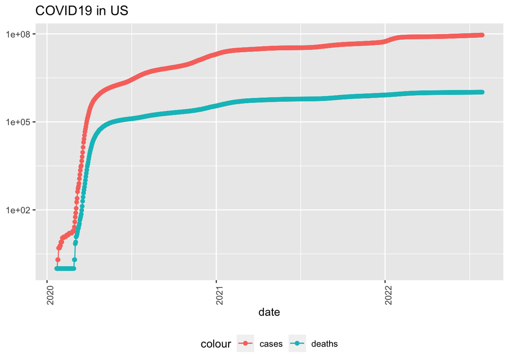

```r
us_totals %>%
  filter(cases > 0) %>%
  ggplot(aes(x = date, y = cases)) +
  geom_line(aes(color = "cases")) +
  geom_point(aes(color = "cases")) +
  geom_line(aes(y = deaths, color = "deaths")) +
  geom_point(aes(y = deaths, color = "deaths")) +
  scale_y_log10() +
  theme(legend.position = "bottom",
        axis.text.x = element_text(angle = 90)) +
  labs(title = "COVID19 in US", y = NULL)
```

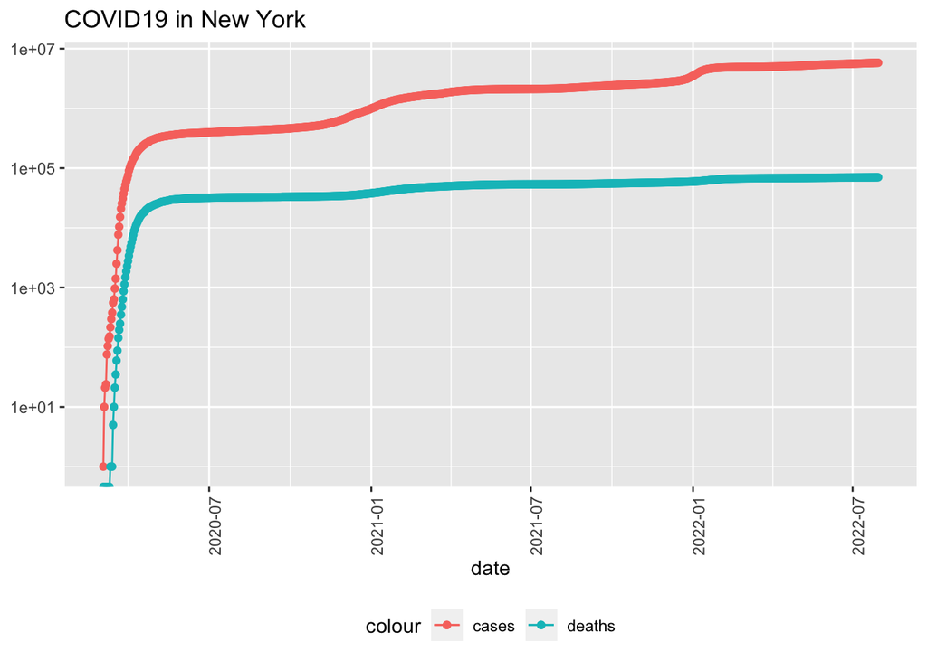

```r
state <- "New York"
us_by_state %>%
  filter(Province_State == state) %>%
  filter(cases > 0) %>%
  ggplot(aes(x = date, y = cases)) +
  geom_line(aes(color = "cases")) +
  geom_point(aes(color = "cases")) +
  geom_line(aes(y = deaths, color = "deaths")) +
  geom_point(aes(y = deaths, color = "deaths")) +
  scale_y_log10() +
  theme(legend.position = "bottom",
        axis.text.x = element_text(angle = 90)) +
  labs(title = str_c("COVID19 in ", state), y = NULL)
```

```r
max(us_totals$date)
```

```
## [1] "2022-07-30"
```

```r
max(us_totals$deaths)
```

```
## [1] 1029925
```

## Analyzing data

Next let’s introduce two new variables: new_cases and new_deaths and plot them in USA and New York.

```r
us_by_state <- us_by_state %>%
  mutate(new_cases = cases - lag(cases),
         new_deaths = deaths - lag(deaths))

us_totals <- us_totals %>%
  mutate(new_cases = cases - lag(cases),
         new_deaths = deaths - lag(deaths))
tail(us_totals %>% select(new_cases, new_deaths, everything()))
```

| new_cases | new_deaths | Country_Region | date | cases | deaths | deaths_per_mill | Population |
| --- | --- | --- | --- | --- | --- | --- | --- |
| 188900 | 418 | US | 2022-07-25 | 90598955 | 1027423 | 3086.512 | 332875137 |
| 134725 | 517 | US | 2022-07-26 | 90733680 | 1027940 | 3088.065 | 332875137 |
| 239176 | 933 | US | 2022-07-27 | 90972856 | 1028873 | 3090.868 | 332875137 |
| 147362 | 397 | US | 2022-07-28 | 91120218 | 1029270 | 3092.060 | 332875137 |
| 180053 | 633 | US | 2022-07-29 | 91300271 | 1029903 | 3093.962 | 332875137 |
| 8888 | 22 | US | 2022-07-30 | 91309159 | 1029925 | 3094.028 | 332875137 |

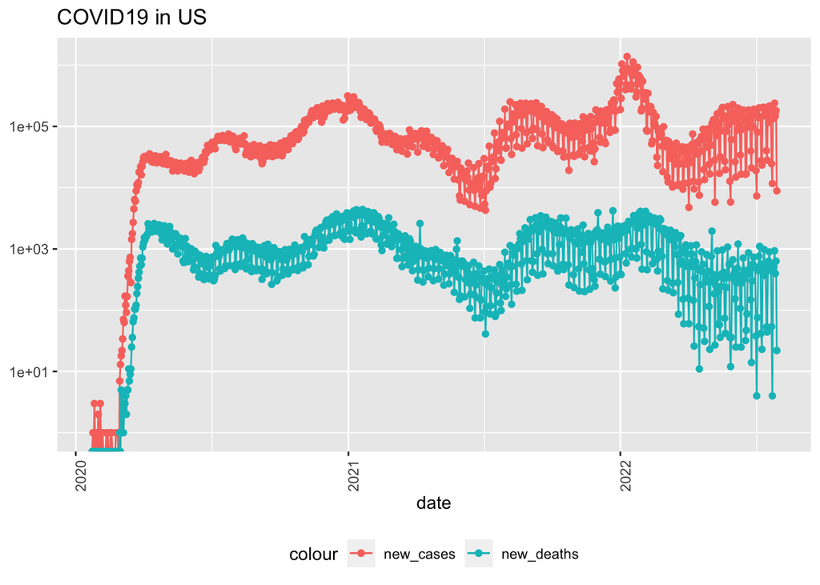

```r
us_totals %>%
  ggplot(aes(x = date, y = new_cases)) +
  geom_line(aes(color = "new_cases")) +
  geom_point(aes(color = "new_cases")) +
  geom_line(aes(y = new_deaths, color = "new_deaths")) +
  geom_point(aes(y = new_deaths, color = "new_deaths")) +
  scale_y_log10() +
  theme(legend.position = "bottom",
        axis.text.x = element_text(angle = 90)) +
  labs(title = "COVID19 in US", y = NULL)
```

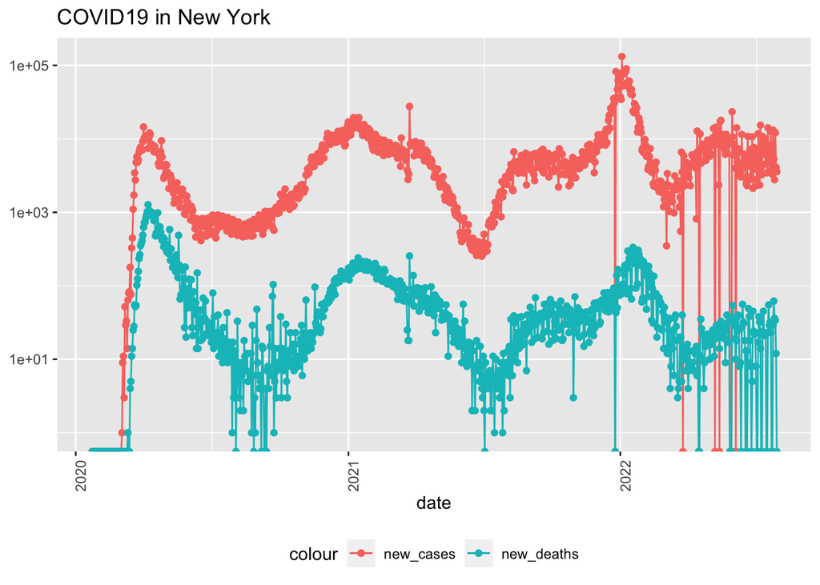

```r
state <- "New York"
us_by_state %>%
  filter(Province_State == state) %>%
  ggplot(aes(x = date, y = new_cases)) +
  geom_line(aes(color = "new_cases")) +
  geom_point(aes(color = "new_cases")) +
  geom_line(aes(y = new_deaths, color = "new_deaths")) +
  geom_point(aes(y = new_deaths, color = "new_deaths")) +
  scale_y_log10() +
  theme(legend.position = "bottom",
        axis.text.x = element_text(angle = 90)) +
  labs(title = str_c("COVID19 in ", state), y = NULL)
```

```r
us_state_totals <- us_by_state %>%
  group_by(Province_State) %>%
  summarize(deaths = max(deaths), cases = max(cases),
            population = max(Population),
            cases_per_thou = 1000 * cases / population,
            deaths_per_thou = 1000 * deaths / population) %>%
  filter(cases > 0, population > 0)

us_state_totals %>%
  slice_min(deaths_per_thou, n = 10) %>%
  select(deaths_per_thou, cases_per_thou, everything())
```

| deaths_per_thou | cases_per_thou | Province_State | deaths | cases | population |
| --- | --- | --- | --- | --- | --- |
| 0.5930878 | 134.2715 | American Samoa | 33 | 7471 | 55641 |
| 0.6709705 | 228.0030 | Northern Mariana Islands | 37 | 12573 | 55144 |
| 1.1095636 | 230.2073 | Hawaii | 1571 | 325944 | 1415872 |
| 1.1105965 | 220.5952 | Vermont | 693 | 137649 | 623989 |
| 1.1186934 | 202.9962 | Virgin Islands | 120 | 21775 | 107268 |
| 1.2695279 | 226.6420 | Puerto Rico | 4767 | 851027 | 3754939 |
| 1.5284043 | 315.1295 | Utah | 4900 | 1010292 | 3205958 |
| 1.7665436 | 382.7867 | Alaska | 1309 | 283643 | 740995 |
| 1.7864992 | 227.1797 | Washington | 13604 | 1729949 | 7614893 |
| 1.8352760 | 205.3225 | Maine | 2467 | 275997 | 1344212 |

```r
us_state_totals %>%
  slice_max(deaths_per_thou, n = 10) %>%
  select(deaths_per_thou, cases_per_thou, everything())
```

| deaths_per_thou | cases_per_thou | Province_State | deaths | cases | population |
| --- | --- | --- | --- | --- | --- |
| 4.249787 | 294.0484 | Mississippi | 12648 | 875132 | 2976149 |
| 4.227119 | 301.7605 | Arizona | 30768 | 2196429 | 7278717 |
| 4.107182 | 283.2808 | Oklahoma | 16252 | 1120934 | 3956971 |
| 4.056751 | 290.5073 | Alabama | 19891 | 1424411 | 4903185 |
| 3.992976 | 309.7441 | West Virginia | 7156 | 555107 | 1792147 |
| 3.954505 | 321.9930 | Tennessee | 27006 | 2198946 | 6829174 |
| 3.932605 | 281.8737 | New Mexico | 8246 | 591041 | 2096829 |
| 3.883287 | 299.4081 | Arkansas | 11719 | 903555 | 3017804 |
| 3.856369 | 290.7496 | New Jersey | 34253 | 2582493 | 8882190 |
| 3.779690 | 296.3491 | Louisiana | 17571 | 1377666 | 4648794 |

## Model data in the USA

Here we will use linear model to build a model of a dependency between deaths per thousand and cases per thousand. When we have model, we can then plot it against real data that we have.

```r
mod <- lm(deaths_per_thou ~ cases_per_thou, data = us_state_totals)
summary(mod)
```

```
##
## Call:
## lm(formula = deaths_per_thou ~ cases_per_thou, data = us_state_totals)
##
## Residuals:
##     Min      1Q  Median      3Q     Max
## -2.3267 -0.5683  0.1173  0.7168  1.1550
##
## Coefficients:
##                 Estimate Std. Error t value Pr(>|t|)
## (Intercept)    -0.213727   0.688778  -0.310    0.758
## cases_per_thou  0.011252   0.002491   4.518 3.44e-05 ***
## ---
## Signif. codes:  0 '***' 0.001 '**' 0.01 '*' 0.05 '.' 0.1 ' ' 1
##
## Residual standard error: 0.834 on 54 degrees of freedom
## Multiple R-squared:  0.2743, Adjusted R-squared:  0.2608
## F-statistic: 20.41 on 1 and 54 DF,  p-value: 3.443e-05
```

```r
us_state_totals %>% slice_min(cases_per_thou)
```

| Province_State | deaths | cases | population | cases_per_thou | deaths_per_thou |
| --- | --- | --- | --- | --- | --- |
| American Samoa | 33 | 7471 | 55641 | 134.2715 | 0.5930878 |

```r
us_state_totals %>% slice_max(cases_per_thou)
```

| Province_State | deaths | cases | population | cases_per_thou | deaths_per_thou |
| --- | --- | --- | --- | --- | --- |
| Rhode Island | 3630 | 410399 | 1059361 | 387.4024 | 3.426594 |

```r
us_state_totals %>% mutate(pred = predict(mod))
```

| Province_State | deaths | cases | population | cases_per_thou | deaths_per_thou | pred |
| --- | --- | --- | --- | --- | --- | --- |
| Alabama | 19891 | 1424411 | 4903185 | 290.5073 | 4.0567509 | 3.054950 |
| Alaska | 1309 | 283643 | 740995 | 382.7867 | 1.7665436 | 4.093242 |
| American Samoa | 33 | 7471 | 55641 | 134.2715 | 0.5930878 | 1.297044 |
| Arizona | 30768 | 2196429 | 7278717 | 301.7605 | 4.2271186 | 3.181566 |
| Arkansas | 11719 | 903555 | 3017804 | 299.4081 | 3.8832873 | 3.155098 |
| California | 93491 | 10702564 | 39512223 | 270.8672 | 2.3661286 | 2.833966 |
| Colorado | 12986 | 1596242 | 5758736 | 277.1862 | 2.2550087 | 2.905065 |
| Connecticut | 11102 | 854110 | 3565287 | 239.5628 | 3.1139148 | 2.481741 |
| Delaware | 3024 | 294041 | 973764 | 301.9633 | 3.1054752 | 3.183848 |
| District of Columbia | 1364 | 162519 | 705749 | 230.2788 | 1.9326985 | 2.377281 |

[output cut: 46 more lines]

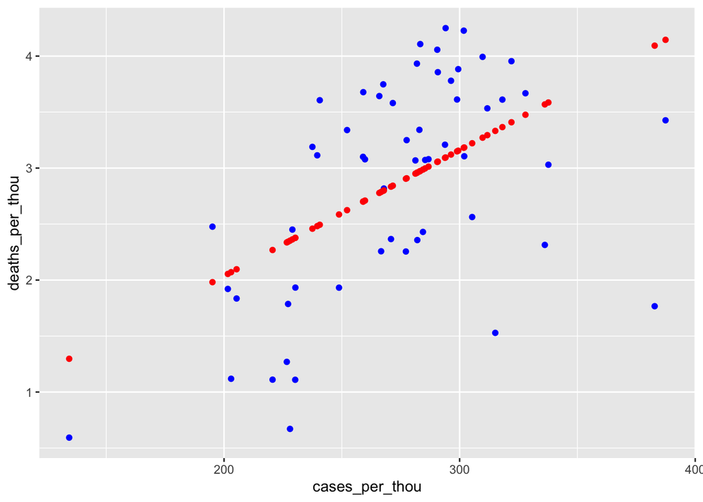

```r
us_tot_w_pred <- us_state_totals %>% mutate(pred = predict(mod))
us_tot_w_pred %>% ggplot() +
  geom_point(aes(x = cases_per_thou, y = deaths_per_thou), color = "blue") +
  geom_point(aes(x = cases_per_thou, y = pred), color = "red")
```

### Analyze worldwide data

let’s plot a graph of global deaths and global cases and then a graph of cases and deaths in China. For China I can clearly see huge increase in number of cases for 2022.

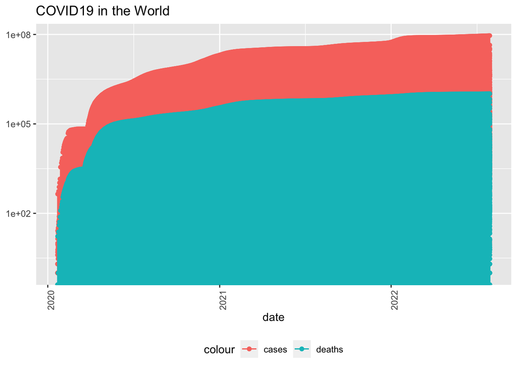

```r
global %>%
  filter(cases > 0) %>%
  ggplot(aes(x = date, y = cases)) +
  geom_line(aes(color = "cases")) +
  geom_point(aes(color = "cases")) +
  geom_line(aes(y = deaths, color = "deaths")) +
  geom_point(aes(y = deaths, color = "deaths")) +
  scale_y_log10() +
  theme(legend.position = "bottom",
        axis.text.x = element_text(angle = 90)) +
  labs(title = "COVID19 in the World", y = NULL)
```

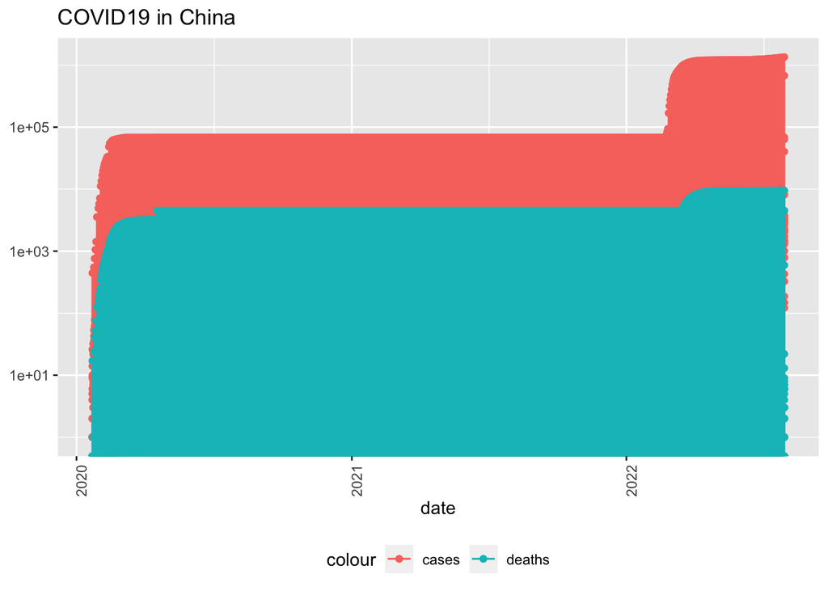

```r
country <- "China"
global %>%
  filter(Country_Region == country) %>%
  filter(cases > 0) %>%
  ggplot(aes(x = date, y = cases)) +
  geom_line(aes(color = "cases")) +
  geom_point(aes(color = "cases")) +
  geom_line(aes(y = deaths, color = "deaths")) +
  geom_point(aes(y = deaths, color = "deaths")) +
  scale_y_log10() +
  theme(legend.position = "bottom",
        axis.text.x = element_text(angle = 90)) +
  labs(title = str_c("COVID19 in ", country), y = NULL)
```

### Linear model for global data

Next let’s build linear model for global data and try to find a model for a number of cases and number of deaths dependency.

```r
mod <- lm(cases ~ deaths, data = global)
summary(mod)
```

```
##
## Call:
## lm(formula = cases ~ deaths, data = global)
##
## Residuals:
##       Min        1Q    Median        3Q       Max
## -14998550       -94      3339     11430  29321953
##
## Coefficients:
##               Estimate Std. Error  t value Pr(>|t|)
## (Intercept) -3.207e+03  3.378e+03   -0.949    0.342
## deaths       6.019e+01  5.747e-02 1047.234   <2e-16 ***
## ---
## Signif. codes:  0 '***' 0.001 '**' 0.01 '*' 0.05 '.' 0.1 ' ' 1
##
## Residual standard error: 1629000 on 242770 degrees of freedom
## Multiple R-squared:  0.8188, Adjusted R-squared:  0.8188
## F-statistic: 1.097e+06 on 1 and 242770 DF,  p-value: < 2.2e-16
```

### Bias analysis

As any human I have lots of biases. For example I can have a biases towards some specific countries. I think there are two possible solutions to mitigate that:

1. Analyze data in all possible combinations with all possible types of visualizations. That’s ideal solution but quite often it’s just not feasible
2. Work only with unpersonalized data, for example instead of Categorical country_region columns it’s possible to use some numbers instead (for example 0 - Afghanistan and 1 - China, etc…)